# Team 01 World Bank

## 1.3 Importing the Data to RStudio

**Click to expand/collapse**

```r
library(tidyverse)
```

**Click to expand/collapse**

```r
population <- read_csv("population.csv")
```

**Click to expand/collapse**

```r
indicator <- read_csv("indicator.csv")
```

**Click to expand/collapse**

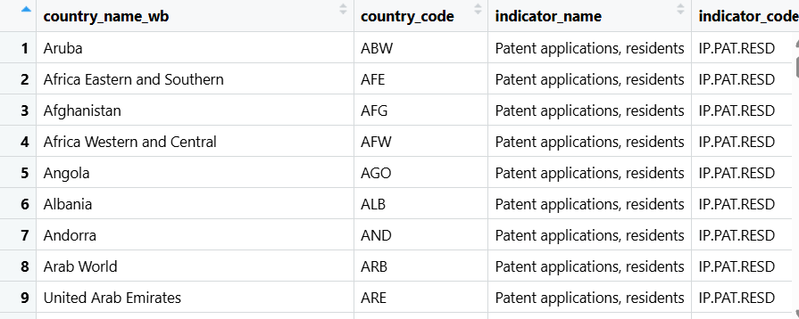

```r
#| label: fig-indicator
#| fig-cap: "Screenshot of Imported indicator Table"
#| echo: false

knitr::include_graphics("indicator_screenshot.png")
```

**Click to expand/collapse**

```r
#| echo: true
country_codes <- read_csv("country_codes.csv")
```

**Click to expand/collapse**

```r
#| echo: true
nrow(population)
```

```
[1] 266
```

**Click to expand/collapse**

```r
nrow(indicator)
```

```
[1] 266
```

**Click to expand/collapse**

```r
#| echo: true
population_reduced <- population |>
  semi_join(country_codes, by = "country_code")

#| echo: true
#| eval: true

indicator_reduced <- indicator |>
  semi_join(country_codes, by = "country_code")

#| echo: true
nrow(population_reduced)
```

```
[1] 217
```

**Click to expand/collapse**

```r
nrow(indicator_reduced)
```

```
[1] 217
```

## 1.4 Removing Rows not Pertaining to Countries

### 1.4.1 Importing the country_codes Table

### 1.4.2 Checking the Number of Rows in`population` and `indicator`

### 1.4.3 Removing Non-Country Rows

### 1.4.4 Checking the Number of Rows in the Reduced Tables

## 1.5 Analyzing Country-Level Data

### 1.5.1 Generating the Rankings

| country_name | country_code | population | indicator_value | rank_by_population | rank_by_indicator |
| --- | --- | --- | --- | --- | --- |
| China | CHN | 1412360000 | 1426644 | 1 | 1 |
| United States | USA | 332031554 | 262244 | 3 | 2 |
| Japan | JPN | 125681593 | 222452 | 10 | 3 |
| Korea, Rep. | KOR | 51744876 | 186245 | 23 | 4 |
| Germany | DEU | 83196078 | 39822 | 16 | 5 |
| India | IND | 1407563842 | 26267 | 2 | 6 |
| Russian Federation | RUS | 144130482 | 19569 | 8 | 7 |
| France | FRA | 67764304 | 13386 | 18 | 8 |
| United Kingdom | GBR | 67026292 | 11592 | 19 | 9 |
| Italy | ITA | 59133173 | 10281 | 21 | 10 |

| country_name | country_code | indicator_per_capita | rank_per_capita |
| --- | --- | --- | --- |
| Korea, Rep. | KOR | 0.0035992936 | 1 |
| Japan | JPN | 0.0017699648 | 2 |
| China | CHN | 0.0010101136 | 3 |
| United States | USA | 0.0007898165 | 4 |
| Germany | DEU | 0.0004786524 | 5 |
| Singapore | SGP | 0.0003711333 | 6 |
| Finland | FIN | 0.0002809953 | 7 |
| Barbados | BRB | 0.0002596017 | 8 |
| Austria | AUT | 0.0002090266 | 9 |
| San Marino | SMR | 0.0002074381 | 10 |

| year | total_countries |
| --- | --- |
| 2021 | 30 |

| country_name | country_code | population | indicator_per_capita |
| --- | --- | --- | --- |
| India | IND | 1407563842 | 1.866132e-05 |
| Indonesia | IDN | 273753191 | 5.103137e-06 |
| Pakistan | PAK | 231402117 | 1.840951e-06 |
| Bangladesh | BGD | 169356251 | 4.369487e-07 |
| Mexico | MEX | 126705138 | 8.815744e-06 |
| Philippines | PHL | 113880328 | 4.302762e-06 |
| Egypt, Arab Rep. | EGY | 109262178 | 8.063174e-06 |
| Viet Nam | VNM | 97468029 | 1.093692e-05 |
| Thailand | THA | 71601103 | 1.210875e-05 |
| Kenya | KEN | 53005614 | 3.018548e-06 |

### 1.5.2 Analyzing the Results

In the first ranking table (top 10 by raw indicator value), the leaders are mostly large, innovation‑intensive economies, so it makes sense that high‑population countries such as China, the United States, and India appear near the top: scale tends to increase the number of inventors, firms, and R&D activity, raising total resident patent applications. However, population does not fully explain the ordering—Japan, Korea (Rep.), and Germany rank highly despite smaller populations, implying that innovation capacity, industrial structure, and R&D intensity can outweigh sheer size.

In the second table (top 10 by indicator per capita), the ranking shifts because normalizing by population highlights countries with high patenting activity relative to population, not just high totals. As a result, rankings align for countries that combine large volumes with strong innovation intensity, but diverge when very populous countries’ totals look modest per person and smaller, innovation‑dense economies move up.

The “large population but low per‑capita indicator” result explains why the two rankings can differ. Some countries rank high on the raw indicator because scale boosts total output, but they drop when the metric is normalized by population. Compared with the per‑capita table, this group reflects weaker innovation intensity per person despite having many people. This suggests that factors like R&D intensity, industrial structure, and how broadly innovation activity is spread matter more than population size alone.

# 2 `R` Task (25%)

## 2.1 Creating and Visualizing `swish()`

**Click to expand/collapse**

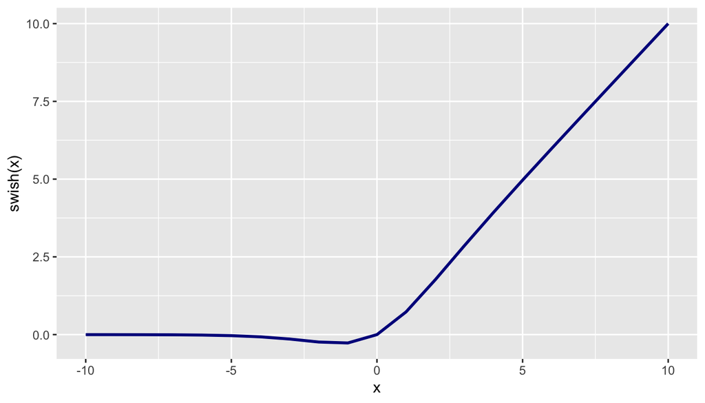

Figure 1: Swish Activation Function

```r
# Your `swish()` function here
swish <- function(x) {
  x / (1 + exp(-x))
}

library(ggplot2)
library(tibble)

x <- -10:10
y <- swish(x)
tbl_swish <- tibble(x, y)

ggplot(tbl_swish, aes(x, y)) +
  geom_line(color = "darkblue", linewidth = 1) +
  labs(x = "x", y = "swish(x)")
```

## 2.2 Visualizing the Gradient of `swish()`

**Click to expand/collapse**

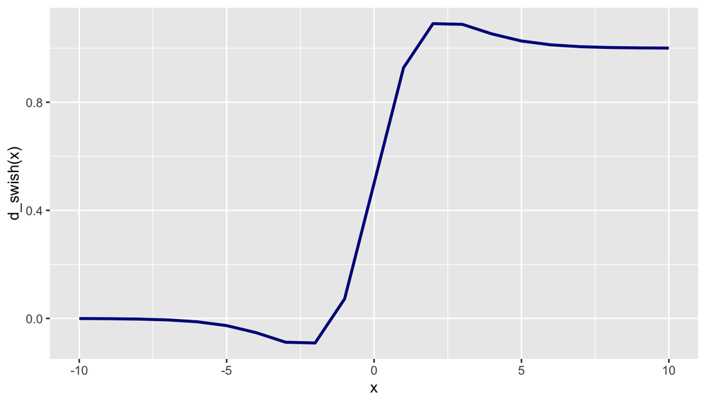

Figure 2: Gradient of Swish Activation Function

```r
# Your `d_swish()` function here

sigmoid <- function(x) 1 / (1 + exp(-x))

d_swish <- function(x) {
  s <- swish(x)
  sig <- sigmoid(x)
  return(s + sig * (1 - s))
}

x <- -10:10
y <- d_swish(x)
tbl_d_swish <- tibble(x, y)

ggplot(tbl_d_swish, aes(x, y)) +
  geom_line(color = "darkblue", linewidth = 1) +
  labs(x = "x", y = "d_swish(x)")
```

Swish offers superior training performance because its gradient is smooth and non-monotonic, allowing for a small flow of information even for negative values. This smoothness helps deep networks converge more effectively and leads to higher accuracy rates. The compromise is that Swish is significantly more computationally expensive than ReLU because it requires calculating exponential functions and divisions, which can increase the overall time for each training iteration.

## 2.3 Toy Examples Calling `swish()` and `ReLU()`

**Click to expand/collapse**

```r
# median ID of team
student_ids <- c(2400951, 2401493, 2402311, 2503741, 2502643)

median_id <- median(student_ids)

set.seed(median_id)

# 10 element random vector between -10 and 10
random_vector <- runif(10, min = -10, max = 10)

# Activating the vector
activated_vector <- swish(random_vector)

# Display results to 2 decimal places
round(random_vector, 2)
```

```
 [1] -9.94 -6.01 -5.11 -0.76 -8.05 -5.69 -5.57  6.21 -0.82 -2.22
```

**Click to expand/collapse**

```r
round(activated_vector, 2)
```

```
 [1]  0.00 -0.01 -0.03 -0.24  0.00 -0.02 -0.02  6.20 -0.25 -0.22
```

**Click to expand/collapse**

```r
# ReLU function
relu <- function(x) pmax(0, x)

# Activate the vector using ReLU
relu_activated_vector <- relu(random_vector)

# Display ReLU results
round(relu_activated_vector, 2)
```

```
 [1] 0.00 0.00 0.00 0.00 0.00 0.00 0.00 6.21 0.00 0.00
```

Yes, swish avoids dead neurons. In the results, for every negative value in the random_vector, the relu_activated_vector produces exactly 0.00. This is evident for all negative inputs, indicating that those neurons are “dead” since they output zero and their gradients will also be zero.

In contrast, the swish activated_vector produces non-zero negative values for those same negative inputs. Because the output is not zero, the gradient remains active, allowing the neuron to continue updating and learning.

## 2.4 Exploring Other Activation Functions

**Click to expand/collapse**

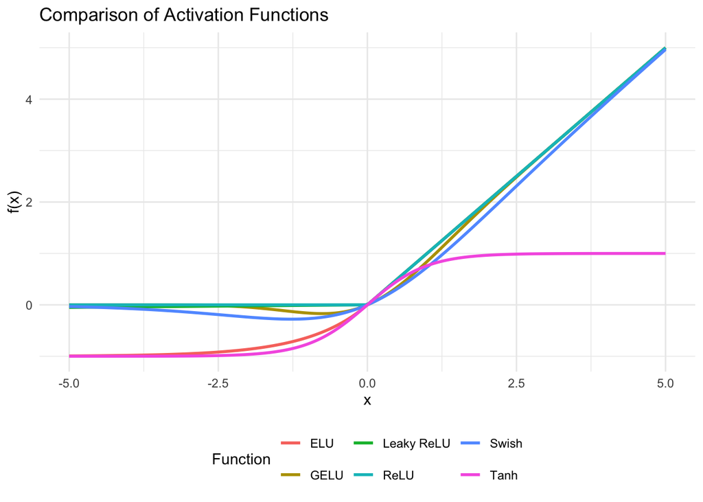

```r
# Define additional activation functions
leaky_relu <- function(x, alpha = 0.01) {
  return(ifelse(x > 0, x, alpha * x))
}

elu <- function(x, alpha = 1.0) {
  return(ifelse(x > 0, x, alpha * (exp(x) - 1)))
}

gelu <- function(x) {
  return(0.5 * x * (1 + tanh(sqrt(2/pi) * (x + 0.044715 * x^3))))
}

# Visualize all functions
x_range <- seq(-5, 5, length.out = 200)

activation_data <- data.frame(
  x = rep(x_range, 6),
  y = c(relu(x_range), swish(x_range), leaky_relu(x_range),
        elu(x_range), gelu(x_range), tanh(x_range)),
  Function = rep(c("ReLU", "Swish", "Leaky ReLU", "ELU", "GELU", "Tanh"),
                 each = length(x_range))
)

ggplot(activation_data, aes(x = x, y = y, color = Function)) +
  geom_line(linewidth = 1) +
  labs(x = "x", y = "f(x)", title = "Comparison of Activation Functions") +
  theme_minimal() +
  theme(legend.position = "bottom")
```

Leaky ReLU: Modified ReLU with small negative slope (typically α=0.01) for negative inputs, defined as f(x) = max(αx, x). This prevents dead neurons while maintaining computational efficiency. Used in CNNs and general deep learning architectures.

ELU (Exponential Linear Unit): Smooth activation function f(x) = x for x>0 and α(e^x - 1) for x≤0. Produces negative outputs that can push mean activations closer to zero, enabling self-normalization. More robust to noise but computationally expensive due to exponential calculation.

GELU (Gaussian Error Linear Unit): Smooth, non-monotonic activation popular in transformer models like BERT and GPT. Approximated as f(x) ≈ 0.5x(1 + tanh(√(2/π)(x + 0.044715x³))). Provides state-of-the-art performance in NLP tasks but requires more computation than ReLU variants.

# 3 Reflection on the Use of GenAI (15%)

#### 3.0.0.1 Understanding vs. Completion

GenAI made it easy to “complete” tasks without truly “understanding” them. We had to consciously resist this and invest time in:

- Reading through generated code line by line
- Testing code with different inputs to see what happens
- Explaining the code to each other in our own words

### 3.0.1 Our Key Takeaways

#### 3.0.1.1 What We Learned About Using GenAI Effectively

1. Understand first, then use AI - Try solving problems ourselves before consulting AI
2. Ask for explanations, not just solutions - Request “why” and “how” alongside code
3. Iterate and customize - Use AI suggestions as starting points, then adapt them
4. Verify and validate - Always test AI-generated code and check if it makes sense
5. Learn the fundamentals - AI is most helpful when we already have basic understanding

#### 3.0.1.2 Our Honest Reflection

GenAI has been incredibly helpful, but it’s also been a double-edged sword. The ease of getting answers made it tempting to skip the struggle of learning. However, we discovered that:

> The struggle is where the learning happens.

When we blindly copied code, we learned nothing. When we used AI to understand concepts and then wrote our own code, we learned deeply.

#### 3.0.1.3 Moving Forward

We plan to use GenAI more strategically:

- Use it to understand errors after we’ve tried debugging ourselves
- Ask it to explain concepts we find confusing in lectures
- Request it to review our code and suggest improvements
- Avoid copying code without understanding each line
- Stop using it as a crutch to avoid thinking through problems
- Don’t let it prevent us from developing independent problem-solving skills

### 3.0.2 Final Thoughts

GenAI tools like Claude and Gemini have transformed how we approach learning data science. They’ve made us more efficient and confident, but they’ve also revealed an important truth: technology can assist learning, but it cannot replace the process of learning itself.

The real skill isn’t just writing code that works—it’s understanding *why* it works, *when* to use different approaches, and *how* to adapt solutions to new problems. GenAI can help us get there faster, but only if we remain active, critical learners who use these tools thoughtfully.

As we continue in this field, we believe the most valuable professionals won’t be those who can prompt AI the best, but those who can combine AI assistance with deep understanding, critical thinking, and genuine problem-solving ability.